# Проверка гипотез в R

Lulin Dmitry

2024-11-28

### 1.1. Импорт данных для работы

Подключаем необходимую для считывания данных библиотеку.

```r
library('rio')
```

Импортируем наш файл и выбираем соответствующий варианту столбец.

```r
dataframe <- import('R_data.xlsx')
data <- dataframe['v17']
```

```r
head(data)
```

```
##     v17
## 1   102
## 2 101.2
## 3 101.3
## 4 100.8
## 5 105.5
## 6 104.6
```

```r
tail(data)
```

```
##       v17
## 96  105.3
## 97  103.5
## 98  101.5
## 99  103.7
## 100 102.8
## 101   v17
```

В конце выборки имеет одно лишнее значение, уберем его с помощью среза.

```r
data <- data[1:100,]
data <- as.data.frame(as.numeric(data))
```

Переименуем столбец данных в соответствии с исследуемой величиной и проверим еще раз наблюдения.

```r
names(data) <- 'Объем основных фондов'
head(data)
```

```
##   Объем основных фондов
## 1                 102.0
## 2                 101.2
## 3                 101.3
## 4                 100.8
## 5                 105.5
## 6                 104.6
```

```r
tail(data)
```

```
##     Объем основных фондов
## 95                  104.9
## 96                  105.3
## 97                  103.5
## 98                  101.5
## 99                  103.7
## 100                 102.8
```

Теперь можем приступать к второму разделу заданий лабораторной работы.

# Раздел 2. Проверка гипотез.

### 2.1. Тесты на однородность дисперсий независимых выборок

Предположим, что мы имеем две выборки X и Y, извлеченные из двух нормально распределенных независимых генеральных совокупностей X∈N(μ1;σ1);Y∈N(μ2;σ2). Выборки взяты из данных типового расчета и поделены на 2 части: создадим две переменные X и Y, приняв за X первые 50 наблюдений нашей выборки, за Y – последние 50:

```r
x <- data[1:50,]
y <- data[51:100,]
```

За уровень значимости возьмем 0,05.

```r
alpha <- 0.05
```

Для проведения данного теста при оговоренных допущениях используется F-статистика Фишера. Поскольку для теста Фишера используется правосторонняя критическая область, это необходимо указать в качестве аргумента функции как `alternative = "greater"`:

```r
var.test(x,y, alternative = "greater")
```

```
##
##  F test to compare two variances
##
## data:  x and y
## F = 0.98261, num df = 49, denom df = 49, p-value = 0.5244
## alternative hypothesis: true ratio of variances is greater than 1
## 95 percent confidence interval:
##  0.6113435       Inf
## sample estimates:
## ratio of variances
##           0.982606
```

Результаты теста включают: $F_{наблюдаемое}$ = 0.98261, $p−value$ = 0.5244. То есть все, что необходимо для проверки нулевой гипотезы. Так как $p-value$ = 0.5244 больше, чем $\alpha$=0,05, то $H_{0}$ не отвергается. Значит, можно считать на уровне значимости $\alpha$=0,05, что гипотеза о равенстве дисперсий генеральных совокупностей не отвергается на уровне значимости $\alpha$=0,05.Тест, кроме того, выдает выборочное отношение дисперсий двух выборок (здесь 0.982606) и его интервальную оценку (она включает 1 и поэтому гипотеза $H_{0}$ не отвергается).

В нашем случае при использовании правосторонней критической области данного критерия нужна вероятность правого хвоста распределения, т.е. $P[X ≥x]$, поэтому задаем это в функции (по умолчанию она выдает квантиль, левый хвост, т.е. вероятность $P[X <x]$).

```r
qf(alpha,49,49,lower.tail = FALSE)
```

```
## [1] 1.607289
```

Результат показал, что $F_{наблюдаемое}$=0.98261 < $F_{критическое}$=1.607289, следовательно, на уровне значимости 0,05 гипотеза о равенстве дисперсий генеральных совокупностей не отвергается.

### 2.2. Тесты на равенство средних

#### 2.2.1. Сравнение среднего совокупности с заданным значением параметрический тест (t-тест Стьюдента)

Провести этот тест в R можно с помощью стандартной встроенной функции `t.test()`. Данная функция имеет аргумент $μ$, который отвечает за параметр проверяемого среднего значения гипотезы $Ho:μ=μ_{0}$. Найдем среднее введенной нами ранее выборки X. Предположим, что выборка X извлечена из нормально распределенной генеральной совокупности $X∈N(μ_x;σ_x)$. Проверим состав нашей переменной с помощью удобной функции проверки целостности данных `glimpse` из пакета `dplyr`:

```r
library(dplyr)
glimpse(x)
```

```
##  num [1:50] 102 101 101 101 106 ...
```

```r
mean(x)
```

```
## [1] 103.198
```

Получаем результат, показывающий нам, что переменная числовая, состоящая из 50 значений, ее среднее по выборке равно 103.198. Допустим, по нормативу среднее значение Х должно составлять 104. Таким образом, нам по имеющейся в нашем распоряжении выборке необходимо проверить нулевую гипотезу: $H_0:μ=μ_0=104$.

Проведем тест на проверку равенства средней нормативу:

```r
t.test(x,mu = 104)
```

```
##
##  One Sample t-test
##
## data:  x
## t = -3.0871, df = 49, p-value = 0.003322
## alternative hypothesis: true mean is not equal to 104
## 95 percent confidence interval:
##  102.6759 103.7201
## sample estimates:
## mean of x
##   103.198
```

Видим, что $p-value$=0.003322 меньше, чем $α$=0,05. Значит, гипотеза $H_0: 𝜇=104$ отвергается на уровне значимости 0,05 (средняя не соответствует нормативу). Наблюдаемое значение статистики критерия: `t = -3.0871`. Доверительный интервал для генеральной средней по умолчанию строится в рамках теста с надежностью 0,95, в опциях эту вероятность можно изменить.

$P(102.6759<μ<103.7201)$=0.95

Видим, что он не содержит значение норматива 104. Теперь найдем $t_{крит}$.

```r
qt(alpha/2,49)
```

```
## [1] -2.009575
```

$|t_{набл}|$=3.0871>$t_{крит}$.=2.009575. Значит гипотеза $H_0:μ=μ_0=104$ отвергается на уровне значимости $α$=0.05 (средняя не соответствует нормативу).

#### 2.2.2. Сравнение среднего выборки с заданным значением - непараметрический тест Вилкоксона

В случае отклонения распределения изучаемой совокупности от нормального для проверки гипотезы о равенстве средней (медианы) определенному значению используется непараметрический критерий Вилкоксона и функция `wilcox.test`, устроенная аналогично функции `t.test`.В предположении, что распределение отклоняется от нормального, воспользуемся `wilcox.test` для нашей выборки X

```r
wilcox.test(x, mu = 104)
```

```
##
##  Wilcoxon signed rank test with continuity correction
##
## data:  x
## V = 313.5, p-value = 0.001785
## alternative hypothesis: true location is not equal to 104
```

$p−value=0.001785<0.05=α$, следовательно гипотеза $H_0:μ=μ_0=104$ отвергается на уровне значимости $α=0.05$ (средняя не соответствует нормативу).

#### 2.2.3. Сравнение средних двух независимых нормально распределенных совокупностей -параметрический тест (t-тест Стьюдента)

После проведения теста на равенство дисперсий, проведем тест на равенство средних в двух (независимых) выборках, извлеченных из нормальных совокупностей. В нем используется t-статистика Стьюдента. Воспользуемся функцией `t.test()`. На входе функция получает две выборки — $𝑥$ и $𝑦$ — и два параметра: `var.equal` и `paired`.

```r
t.test(x, y, var.equal = TRUE, paired = FALSE)
```

```
##
##  Two Sample t-test
##
## data:  x and y
## t = -2.6936, df = 98, p-value = 0.008315
## alternative hypothesis: true difference in means is not equal to 0
## 95 percent confidence interval:
##  -1.7263038 -0.2616962
## sample estimates:
## mean of x mean of y
##   103.198   104.192
```

Теперь выведем $t_{критическое}$:

```r
qt(0.975, 98)
```

```
## [1] 1.984467
```

Проверим альтернативную гипотезу, что $H_1:μ_x>μ_y$:

```r
t.test(x, y, var.equal = TRUE, alternative = "greater", paired = FALSE)
```

```
##
##  Two Sample t-test
##
## data:  x and y
## t = -2.6936, df = 98, p-value = 0.9958
## alternative hypothesis: true difference in means is greater than 0
## 95 percent confidence interval:
##  -1.606773       Inf
## sample estimates:
## mean of x mean of y
##   103.198   104.192
```

```r
qt(0.975, 98)
```

```
## [1] 1.984467
```

Как можно видеть, $p−value=0.9958>α=0.05$. Гипотеза $H_0:μ_x=μ_y$ не отвергается на уровне значимости $α=0.05$ против гипотезы $H_1:μ_x>μ_y$ (среднее первой совокупности не больше средней второй совокупности).

Для построения этого графика организуем данные в виде таблицы:

```r
my_data <- data.frame(group = rep(c("x", "y"), each = 50),something = c(x, y))
print(my_data)
```

```
##     group something
## 1       x     102.0
## 2       x     101.2
## 3       x     101.3
## 4       x     100.8
## 5       x     105.5
## 6       x     104.6
## 7       x     103.4
## 8       x     105.9
## 9       x     104.7
## 10      x     103.1
## 11      x     103.7
## 12      x     103.6
## 13      x     102.6
## 14      x     104.3
```

[output cut: 86 more lines]

Теперь построим по нашим данным график “ящик с усами”, для этого подключим библиотеку `ggpubr`:

```r
library("ggpubr")
```

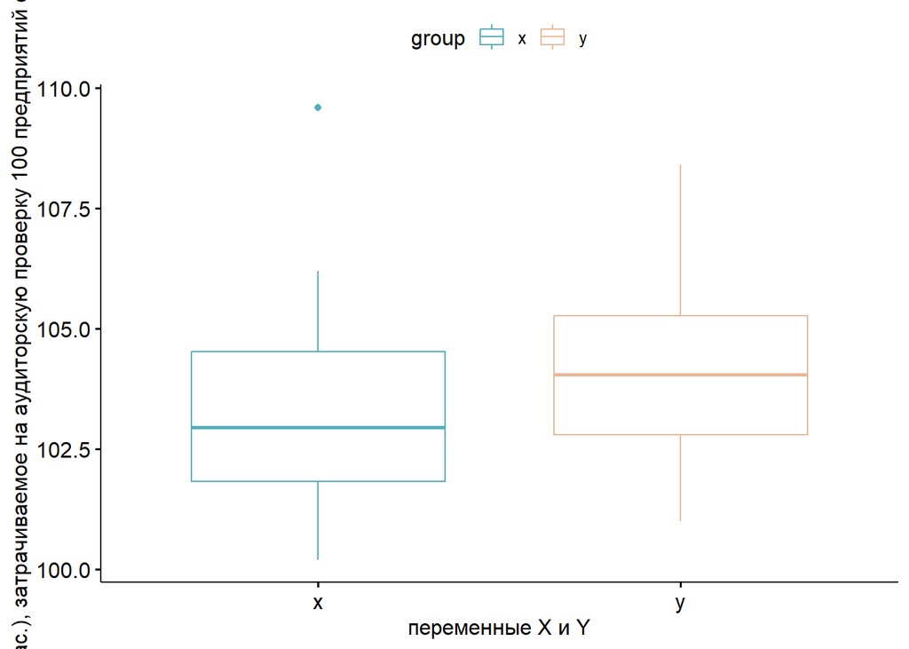

*Рис. 4. Ящичковые диаграммы (boxplots) для переменных Х и У, построенные с помощью функции `ggboxplot` пакета `ggpubr`*

```r
ggboxplot(my_data, x = "group", y = "something", color = "group", palette = c("#55AFBB", "#E7B999"), ylab = "Время (час.), затрачиваемое на аудиторскую проверку 100 предприятий отрасли", xlab = "переменные X и Y")
```

По графику может увидеть небольшую разницу между средними значениями двух выборок.

#### 2.2.4. Сравнение различий двух совокупностей - непараметрический тест Вилкоксона

Для тех же выборок X и Y посмотрим медианы, интерквартильные размахи и тест Вилкоксона для несвязных и связных выборок:

```r
median_x = median(x)
median_x
```

```
## [1] 102.95
```

```r
median_y = median(y)
median_y
```

```
## [1] 104.05
```

```r
IQR_x = IQR(x, na.rm = TRUE)
IQR_y = IQR(y, na.rm = TRUE)
```

```r
IQR_x
```

```
## [1] 2.7
```

```r
IQR_y
```

```
## [1] 2.475
```

```r
wilcox.test(x, y)
```

```
##
##  Wilcoxon rank sum test with continuity correction
##
## data:  x and y
## W = 864.5, p-value = 0.007928
## alternative hypothesis: true location shift is not equal to 0
```

```r
wilcox.test(x, y, paired=TRUE)
```

```
##
##  Wilcoxon signed rank test with continuity correction
##
## data:  x and y
## V = 354, p-value = 0.01027
## alternative hypothesis: true location shift is not equal to 0
```

Можем увидеть, что в обоих случаях (связные и несвязные выборки) значения $p-value$ меньше чем уровень значимости, следовательно гипотеза $H_0$ о незначимости различий между совокупностями отвергается.

### 2.3. Критерии проверки параметров биномиальных распределений

На данном этапе нам предлагается проверить гипотезы из ДКР2. Сначала приведем условие задачи: Производитель утверждает, что средний процент продаж его продукции равен 80%. Магазин провёл продажу пробной партии из 400 единиц, из которой за контрольный срок было продано 280 единиц. В предположении, что генеральная совокупность подчиняется биномиальному закону распределения, проверить на уровне значимости 0,05 следующие гипотезы:

а)Можно ли считать, что утверждение производителя справедливо? Или процент завышен?(проверить против двух соответствующих конкурирующих гипотез).

б) Сравнить продаваемость этой продукции с другой, которой в этом же магазине было продано за контрольный срок 258 единиц из 500 поступивших.

#### 2.3.1. Тест на равенство вероятности успеха в испытании Бернулли определенной константе

Рассматрим пункт а). Можно ли считать, что утверждение производителя справедливо? Или процент завышен?(проверить против двух соответствующих конкурирующих гипотез).

При достаточно больших объемах выборки осуществляется с помощью стандартной встроенной функции с воможностью поправки на непрерывность Йетса (Yates) (идет по умолчанию): $n=400; m=280;α=0.05$; $H_0:p=p_0=0.8$. Первая конкурирующая гипотеза (справедливость утверждения производителя): $H_1:p_1≠0.8$.

```r
prop.test(280, 400, p = 0.8)
```

```
##
##  1-sample proportions test with continuity correction
##
## data:  280 out of 400, null probability 0.8
## X-squared = 24.379, df = 1, p-value = 7.913e-07
## alternative hypothesis: true p is not equal to 0.8
## 95 percent confidence interval:
##  0.6520722 0.7440176
## sample estimates:
##   p
## 0.7
```

```r
prop.test(280, 400, p = 0.8, correct = FALSE)
```

```
##
##  1-sample proportions test without continuity correction
##
## data:  280 out of 400, null probability 0.8
## X-squared = 25, df = 1, p-value = 5.733e-07
## alternative hypothesis: true p is not equal to 0.8
## 95 percent confidence interval:
##  0.6533628 0.7428323
## sample estimates:
##   p
## 0.7
```

В обоих случаях (с поправкой Йетса и без нее) $p-value$ существенно меньше, чем $\alpha$, следовательно гипотеза $H_0$ о том, что генеральная доля равна 0,8 отвергается на уровне значимости 0,05 (утверждение производителя несправедливо)

Аналогично проведем точный биномиальный тест:

```r
binom.test(280, 400, p = 0.8)
```

```
##
##  Exact binomial test
##
## data:  280 and 400
## number of successes = 280, number of trials = 400, p-value = 2.366e-06
## alternative hypothesis: true probability of success is not equal to 0.8
## 95 percent confidence interval:
##  0.6524781 0.7445333
## sample estimates:
## probability of success
##                    0.7
```

Видим, что $p-value = 2.366e-06$, что меньше уровня значимости, следовательно гипотеза отвергается на уровне значимости 0,05.

Все три теста дали близкие результаты $p-value$, которые все меньше уровня значимости $α=0.05$, – следовательно, гипотеза $H_0:p=p_0=0.8$ отвергается на уровне значимости $α=0.05$ против первой конкурирующей гипотезы. (95% интервальная оценка вероятности р также не включает в себя заявленную долю 0.8).

Для этого пункта осталось провести проверку второй конкурирующей гипотезы $H_1: p < p_0 = 0,8$

```r
prop.test(280, 400, p = 0.8, alternative = 'less')
```

```
##
##  1-sample proportions test with continuity correction
##
## data:  280 out of 400, null probability 0.8
## X-squared = 24.379, df = 1, p-value = 3.957e-07
## alternative hypothesis: true p is less than 0.8
## 95 percent confidence interval:
##  0.0000000 0.7374389
## sample estimates:
##   p
## 0.7
```

```r
prop.test(280, 400, p = 0.8, alternative = 'less', correct = FALSE)
```

```
##
##  1-sample proportions test without continuity correction
##
## data:  280 out of 400, null probability 0.8
## X-squared = 25, df = 1, p-value = 2.867e-07
## alternative hypothesis: true p is less than 0.8
## 95 percent confidence interval:
##  0.0000000 0.7362419
## sample estimates:
##   p
## 0.7
```

```r
binom.test(280, 400, p = 0.8, alternative = 'less')
```

```
##
##  Exact binomial test
##
## data:  280 and 400
## number of successes = 280, number of trials = 400, p-value = 1.293e-06
## alternative hypothesis: true probability of success is less than 0.8
## 95 percent confidence interval:
##  0.000000 0.737744
## sample estimates:
## probability of success
##                    0.7
```

$p-value = 1.293e-06$, что меньше 0,05, следовательно основная гипотеза о том, что генеральная доля равна 0,8, отвергается и мы можем полагать, что процент продаж меньше 80.

#### 2.3.2. Тест на равенство вероятностей успеха в испытаниях Бернулли для нескольких биномиально распределенных совокупностей

Рассмотрим пункт б). Сравнить продаваемость этой продукции с другой, которой в этом же магазине было продано за контрольный срок 258 единиц из 500 поступивших.

Проверка гипотезы о равенстве вероятностей (генеральных долей) биномиально распределенных генеральных совокупностей $B(n_i;_pi). H_0:p_1=p_2=...=p_k$ осуществляется с помощью `prop.test()`, где $m$ и $n$ задаются в виде векторов успехов и числа испытаний.

```r
prop.test(x = c(280, 258), n = c(400, 500),correct = FALSE)
```

```
##
##  2-sample test for equality of proportions without continuity correction
##
## data:  c(280, 258) out of c(400, 500)
## X-squared = 31.291, df = 1, p-value = 2.221e-08
## alternative hypothesis: two.sided
## 95 percent confidence interval:
##  0.1212662 0.2467338
## sample estimates:
## prop 1 prop 2
##  0.700  0.516
```

```r
qchisq(0.95,1)
```

```
## [1] 3.841459
```

$p−value=2.221e−08<α=0.05, \chi^{2}_{набл}=31.291>\chi^{2}_{крит}=3.841459$, следовательно, нулевая гипотеза об однородности вероятностей отвергается на уровне значимости $α=0.05$, значит с большой долей вероятности средний процент продаж первой продукции не равен среднему проценту продаж второй продукции.

### 2.4. Критерии согласия эмпирического распределения с теоретическим

#### 2.4.1. Визуализация данных с целью подбора наилучшего теоретического распределения

Прежде чем проверять выборочное эмпирическое распределение на согласие с каким-то теоретическим, необходимо понять, какое теоретическое распределение в принципе можно подобрать – по схожести гистограммы и функции плотности (вероятности) соответствующего распределения. Многие авторы отмечают графические методы как первое, самое простое и весьма эффективное средство проверки распределения на нормальность. И здесь основными методами являются: построение гистограмм и плотностей эмпирического распределения, ящичковых диаграмм, а также построение нормальных квантильных (`Q-Q plot`) и вероятностных (`P-P plot`) графиков.

Построим эмпирическую плотность наших данных. По ее виду, как и по виду гистограммы можно сделать вывод о предполагаемом теоретическом законе распределения.

```r
volume <- data[[1]]
library("ggpubr")
```

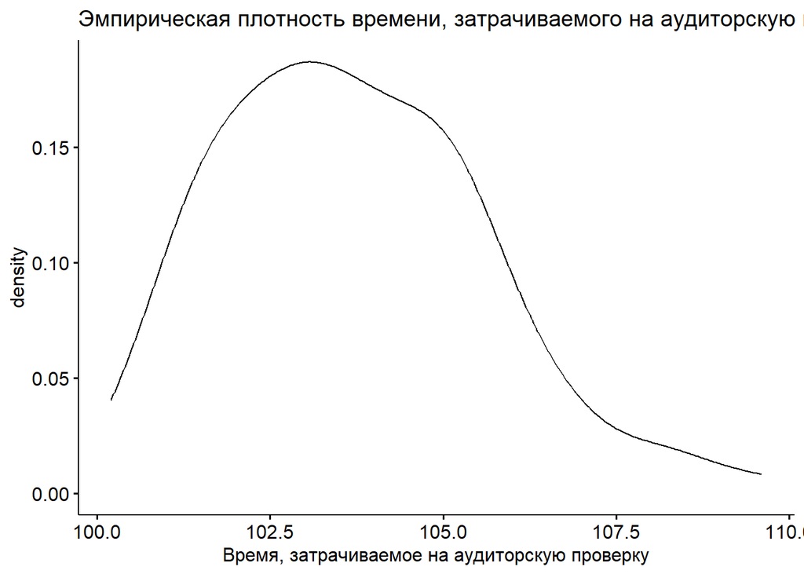

*Рис. 5. Эмпирическая плотность распределения объема основных фондов, построенная с помощью функции `ggdensity` пакета `ggpubr`*

```r
ggdensity(volume,main = "Эмпирическая плотность времени, затрачиваемого на аудиторскую проверку",xlab = "Время, затрачиваемое на аудиторскую проверку")
```

Видим, что рис.5 напоминает нормальную плотность распределения, но с существенной правосторонней ассиметрией.

Построим график типа квантиль-квантиль (`Q-Q plot`) для проверки соответствия квантилей выборки квантилям нормального распределения. Если точки эмпирического распределения близки к прямой под углом 45 градусов на графике – это говорит в пользу нормального распределения генеральной совокупности.

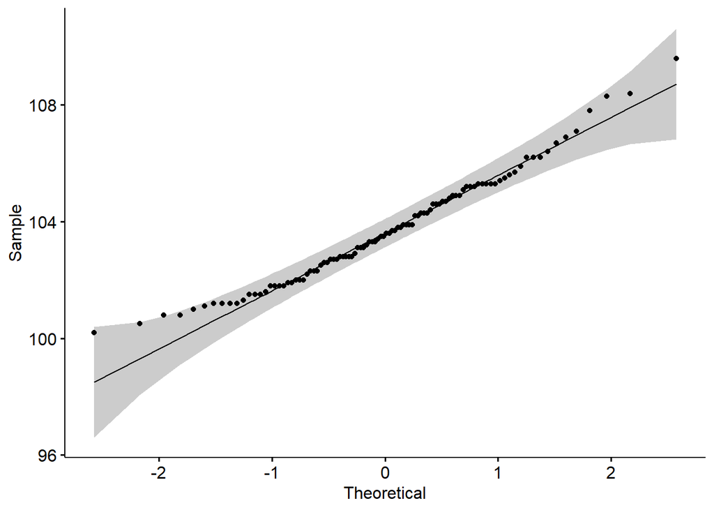

```r
ggqqplot(volume)
```

Видим, что `Q-Q plot` (рис. 6) также позволяет выдвинуть гипотезу о нормальном распределении изучаемой совокупности. Итак, рассмотрим основные критерии проверки согласия выборки с теоретическим распределением и их реализацию в R.

#### 2.4.2. Критерий Колмогорова- Смирнова (Kolmogorov-Smirnov (KS) test)

Проверим согласие нашей переменной из типового расчета с нормальным распределением с параметрами $N(μ=103.695; σ=1.90249)$(напомним, что для применения критерия К.-С. распределение должно быть непрерывным и с заданными параметрами). Определим их примерно подходящими к нашей выборке).

Для этого сгенерируем случайную величину с такими параметрами, посмотрим на нее и проверим согласие с нашей исследуемой

```r
mean(volume)
```

```
## [1] 103.695
```

```r
sd(volume)
```

```
## [1] 1.90249
```

```r
volume_N <- rnorm(100,mean=103.695, sd=1.90249)
```

```r
glimpse(volume_N)
```

```
##  num [1:100] 103 106 101 104 105 ...
```

```r
ks.test(volume, volume_N)
```

```
##
##  Asymptotic two-sample Kolmogorov-Smirnov test
##
## data:  volume and volume_N
## D = 0.07, p-value = 0.9671
## alternative hypothesis: two-sided
```

#### 2.4.3. Критерий Шапиро-Уилка (Shapiro - Wilk test)

```r
shapiro.test(volume)
```

```
##
##  Shapiro-Wilk normality test
##
## data:  volume
## W = 0.9738, p-value = 0.04347
```

Видим, что $p−value=0.04347<α=0.05$, поэтому гипотеза о нормальном распределении отвергается с вероятностью ошибки $α=0.05$.

#### 2.4.4. Тест Жарка-Бера (Jarque-Bera test)

Тест Жарка-Бера предусматривет проверку нормальности распределения двумя методами: классический и робастый.

```r
library(DescTools)
```

```r
JarqueBeraTest(volume, robust = FALSE)
```

```
##
##  Jarque Bera Test
##
## data:  volume
## X-squared = 5.0133, df = 2, p-value = 0.08154
```

```r
JarqueBeraTest(volume, robust = TRUE)
```

```
##
##  Robust Jarque Bera Test
##
## data:  volume
## X-squared = 4.6008, df = 2, p-value = 0.1002
```

В обоих случаях $p−value>α=0.05$ (равняется 0.08154 и 0.1002 для классического и робастого методов соотвественно), поэтому гипотеза о нормальности распределения не отвергается с вероятностью ошибки $α=0.05$.

#### 2.4.5. Критерий Андерсона-Дарлинга

```r
library(nortest)
```

```r
ad.test(volume)
```

```
##
##  Anderson-Darling normality test
##
## data:  volume
## A = 0.54291, p-value = 0.1594
```

$p−value=0.1594>α=0.05$, поэтому гипотеза о нормальности распределения не отвергается с вероятностью ошибки α=0.05.

#### 2.4.6 Критерий Лиллиефорса

```r
lillie.test(volume)
```

```
##
##  Lilliefors (Kolmogorov-Smirnov) normality test
##
## data:  volume
## D = 0.070978, p-value = 0.2472
```

$p−value=0.2472>α=0.05$, поэтому гипотеза о нормальности распределения не отвергается с вероятностью ошибки α=0.05.

#### 2.4.7 Критерий $\chi^2$ Пирсона

```r
pearson.test(volume)
```

```
##
##  Pearson chi-square normality test
##
## data:  volume
## P = 8.42, p-value = 0.5879
```

Видим, что $p−value=0.5879>α=0.05$, поэтому гипотеза о нормальности распределения не отвергается с вероятностью ошибки $\alpha= 0.05$.

#### 2.4.8. Д’Агустино тест (D’Agostino’s K2 test)

```r
library(moments)
```

```r
agostino.test(volume)
```

```
##
##  D'Agostino skewness test
##
## data:  volume
## skew = 0.54671, z = 2.25117, p-value = 0.02438
## alternative hypothesis: data have a skewness
```

$p−value=0.02438<α=0.05$, поэтому гипотеза о нормальности распределения отвергается с вероятностью ошибки α=0.05.

Подводя итоги, разные критерии дали разные $p−value$ и разные результаты о принадлежности распределения к нормальному (критерии Д’Агустино и Шапиро-Уилка отвергли гипотезу о нормальном распеределении, критерии Колмогорова- Смирнова, Жарка-Бера, Пирсона, Лиллиефорса, Андерсона-Дарлинга и о не отвергли эту гипотезу) в связи с разной мощностью, чувствительностью и другими особенностями изученных критериев, поэтомы мы не можем с уверенностью говорить о принадлежности распределения нормальному, гипотеза $H_0$ отвергается.